# Dublin Data Science Workshop on the Statistical Analysis of Networks

Section 2

Mick Cooney mickcooney@gmail.com

Monday, March 26 2018

# 1 Network Statistics

## 1.1 Network Degree

### 1.1.1 Degree of Vertex

The *degree* of a vertex is the count of connections from that vertex.

We now look at the distribution of vertex degree for the Florentine network:

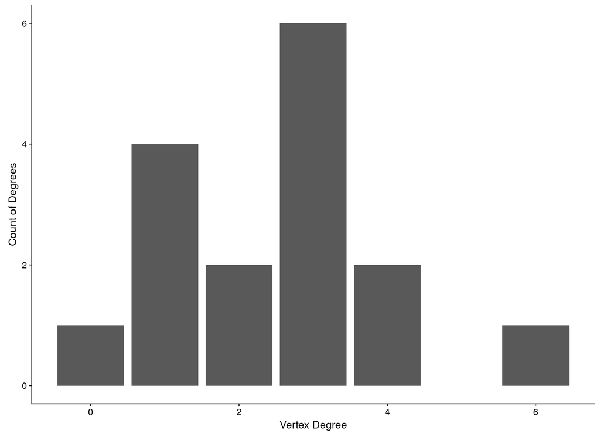

```r
ggplot() +
    geom_bar(aes(x = igraph::degree(florence_igraph))) +
    xlab("Vertex Degree") +
    ylab("Count of Degrees")
```

### 1.1.2 Edge Density

The *edge density* is the ratio of the edge count on the graph with the total possible count of edges on the graph.

From combinatorics, the total possible count of edges is $\frac{N(N-1)}{2}$.

```r
florence_igraph %>% edge_density
```

```
## [1] 0.166667
```

### 1.1.3 Average Neighbour Degree

Another interesting quantity is the average degree of all the neighbours of each vertex.

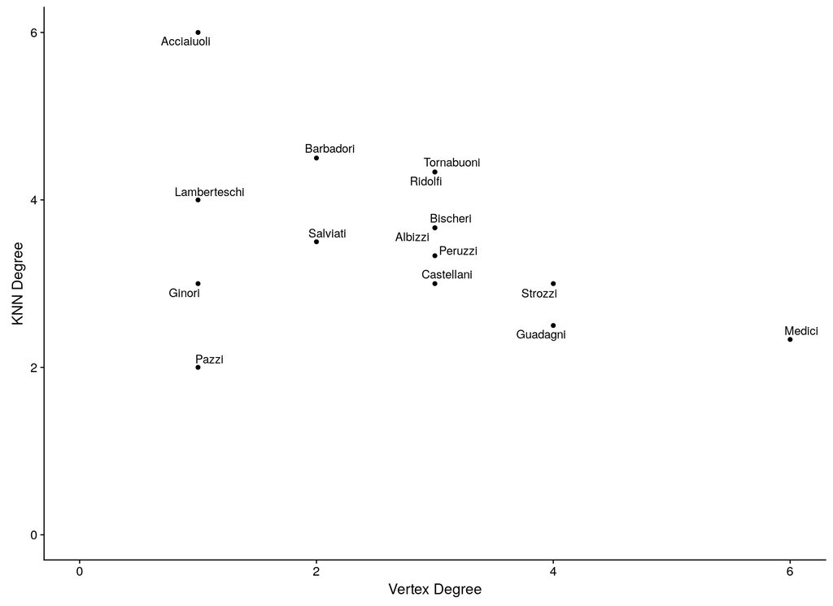

```r
flor_knn <- knn(florence_igraph)$knn

flor_knn_tbl <- data_frame(family = names(flor_knn)
                          ,degree = igraph::degree(florence_igraph)
                          ,knn    = flor_knn
                           )


ggplot(flor_knn_tbl) +
    geom_point(aes(x = degree, y = knn)) +
    geom_text_repel(aes(x = degree, y = knn, label = family)) +
    expand_limits(y = 0) +
    xlab("Vertex Degree") +
    ylab("KNN Degree")
```

### 1.1.4 Exercises

1. Produce the degree distribution for the other networks
2. Calaculate the average neighbour degree distribution for the other networks
3. What can we infer about the importance of a vertex from these values?

## 1.2 Measures of Centrality

### 1.2.1 Between-ness Centrality

Between-ness measures how often a vertex comes between two other vertices in the graph.

$$c_B(\nu) = \sum_{s \neq t \neq \nu \in V} \frac{\sigma(s, t | \nu)}{\sigma(s,t)}$$

where $\sigma(s, t| \nu)$ is the count of shortest paths between $s$ and $t$ that goes through $\nu$ and $\sigma(s, t)$ is the total number of shortest paths between $s$ and $t$.

We now calculate the between-ness centrality for each vertex in the Florence marriage network

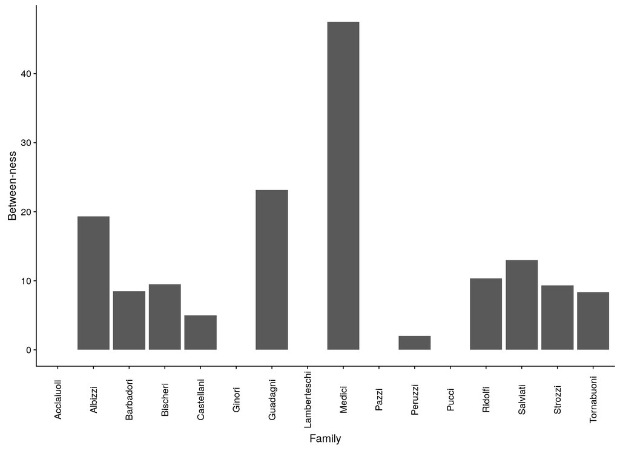

```r
florence_betweenness <- florence_igraph %>%
    (igraph::betweenness)() %>%
    sort(decreasing = TRUE)

ggplot() +
    geom_col(aes(x = names(florence_betweenness), y = florence_betweenness)) +
    xlab("Family") +
    ylab("Between-ness") +
    theme(axis.text.x = element_text(angle = 90, vjust = 0.5))
```

### 1.2.2 Closeness Centrality

Closeness centrality is measure of the distance of the vertex from other vertices in the graph.

$$c_{Cl}(\nu) = \frac{1}{\sum_{u \in V} \text{dist}(u, \nu)}$$

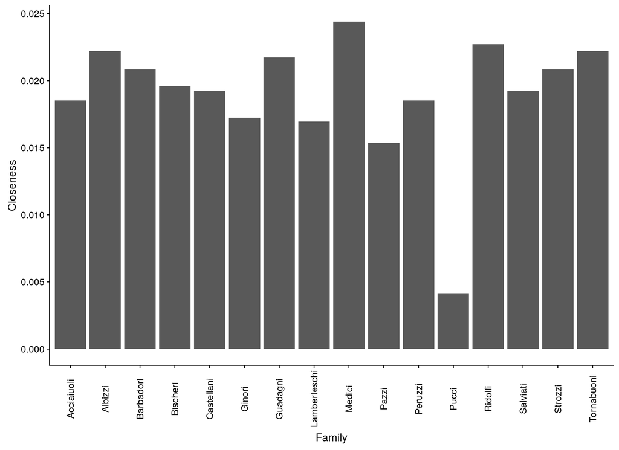

```r
florence_closeness <- florence_igraph %>%
    (igraph::closeness)() %>%
    sort(decreasing = TRUE)

ggplot() +
    geom_col(aes(x = names(florence_closeness), y = florence_closeness)) +
    xlab("Family") +
    ylab("Closeness") +
    theme(axis.text.x = element_text(angle = 90, vjust = 0.5))
```

### 1.2.3 Eigenvector Centrality

Eigenvector centrality is a class of centrality measures based on linear systems derived from the graph.

The most common of these are the eigenvectors of the adjacency matrix produced from the graph.

The key idea here is that vertices which are ‘central’ in the network are so due to their neighbours being ‘central’. This concept is inherently implicit in nature and so is calculated via linear algebra means.

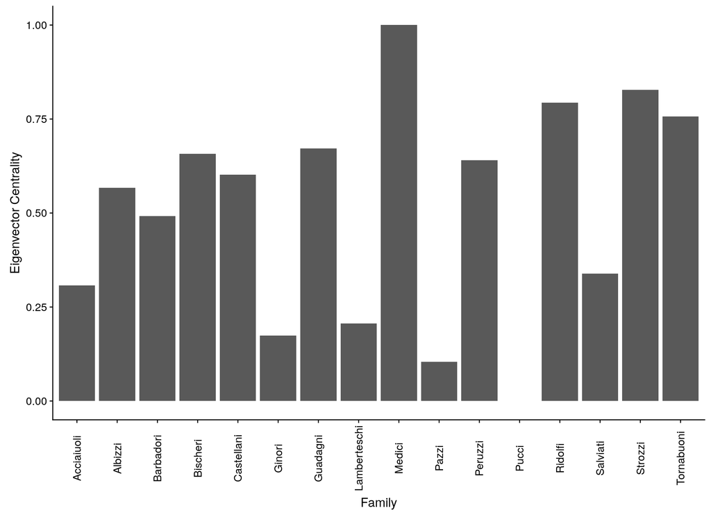

```r
florence_eigencent <- florence_igraph %>%
    eigen_centrality() %>%
    .$vector %>%
    sort(decreasing = TRUE)

ggplot() +
    geom_col(aes(x = names(florence_eigencent), y = florence_eigencent)) +
    xlab("Family") +
    ylab("Eigenvector Centrality") +
    theme(axis.text.x = element_text(angle = 90, vjust = 0.5))
```

### 1.2.4 Articulation Points (Cutpoints)

Another way of thinking about centrality is a point that joins two components - that is, removing the vertex increases the count of components of the graph.

Identifying articulation points may highlight vulnerabilties in the network, or help identify key vertices that would otherwise be overlooked in analysis.

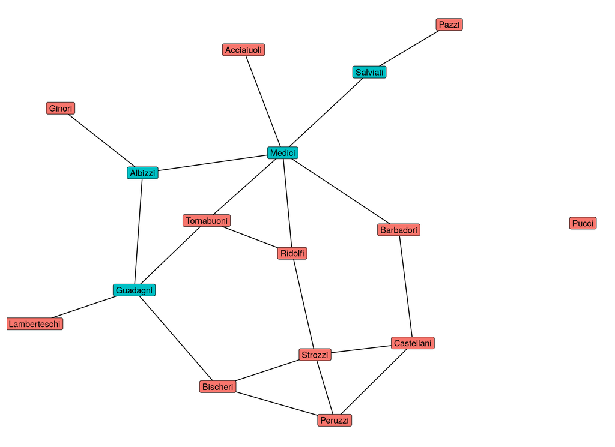

```r
florence_artic <- florence_igraph %>% articulation_points() %>% names()

artic_label_tbl <- data_frame(vertex.names = V(florence_igraph) %>% names()) %>%
    mutate(is_artic = map_lgl(vertex.names, function(x) x %in% florence_artic))

florentine_plot_layout <- florentine_fr_layout %>%
    merge(artic_label_tbl, by = 'vertex.names')

florentine_artic_plot <- ggplot(florentine_plot_layout
                               ,aes(x = x, y = y, xend = xend, yend = yend)) +
    geom_edges() +
    geom_nodelabel(aes(label = vertex.names, fill = is_artic)) +
    theme_blank(legend.position = 'none')

florentine_artic_plot %>% plot()
```

### 1.2.5 Edge Betweenness

Edge betweenness is a similar idea as for between-ness centrality - we want to look at which edges are the most influential in the network.

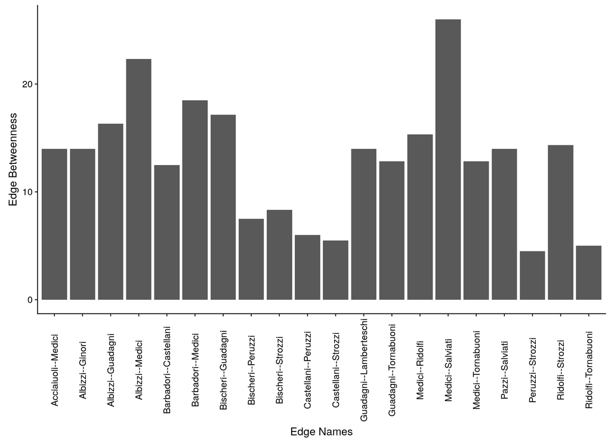

```r
florence_edge_names <- florence_igraph %>%
    as_edgelist() %>%
    as_tibble() %>%
    mutate(edge_name = paste0(V1, '--', V2)) %>%
    pull(edge_name)

florence_edge_betweenness <- florence_igraph %>%
    igraph::edge_betweenness()

florence_edge_between_tbl <- data_frame(
    edge_names       = florence_edge_names
   ,edge_betweenness = florence_edge_betweenness
)


ggplot(florence_edge_between_tbl) +
    geom_col(aes(x = edge_names, y = edge_betweenness)) +
    xlab("Edge Names") +
    ylab("Edge Betweenness") +
    theme(axis.text.x = element_text(angle = 90, vjust = 0.5))
```

### 1.2.6 Line Graphs

Many measures of vertex centrality do not transfer as readily as betweenness centrality. For that reason, we can convert a network into a *line graph* - each edge in the original graph becomes a vertex in its line graph and we connect two of the ‘edge nodes’ with an edge if the edge shares a vertex in the original.

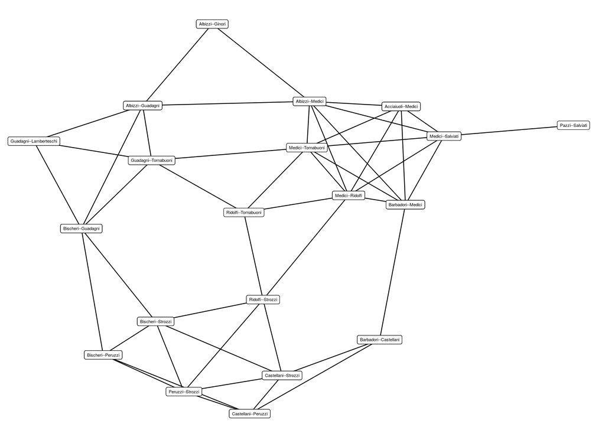

```r
florence_linegraph_igraph <- florence_igraph %>%
    make_line_graph()

florence_linegraph_igraph <- florence_linegraph_igraph %>%
    set_vertex_attr(name = 'name', value = florence_edge_names)


ggplot(florence_linegraph_igraph, aes(x = x, y = y, xend = xend, yend = yend)) +
    geom_edges() +
    geom_label(aes(label = vertex.names), size = 2) +
    theme_blank()
```

We can now use the line graph to discover information about the edges in the original graph.

### 1.2.7 Exercises

1. Calculate the centrality measures for the other networks
2. Construct the line graphs for these networks
3. Discover the important edges using the line graphs

## 1.3 Network Cohesion

### 1.3.1 Cliques

A *clique* is a ‘maximally-connected subgraph’, that is, it is a subset of the nodes of the graph that are all connected to one another.

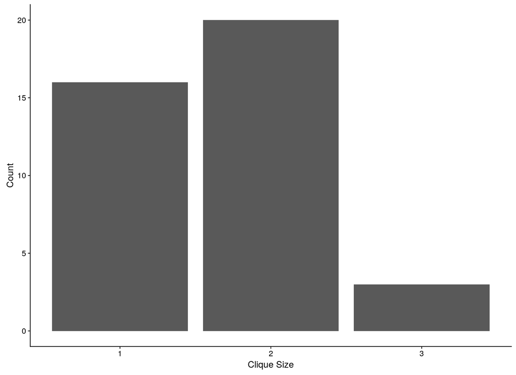

```r
clique_size <- florence_igraph %>%
    cliques %>%
    map_int(length)

ggplot() +
    geom_bar(aes(x = clique_size)) +
    xlab("Clique Size") +
    ylab("Count")
```

### 1.3.2 Clustering Co-efficient / Transitivity

The transitivity of the network is a measure of the ‘density’ of connections in the network. It is the ratio of triangles in the network to possible triangles.

Local transitivity does the same for all triangles contain the vertex.

```r
florence_igraph %>%
    transitivity()
```

```
## [1] 0.191489
```

```r
florence_igraph %>%
    transitivity(type = 'local', vids = c('Strozzi', 'Guadagni', 'Medici'))
```

```
## [1] 0.3333333 0.0000000 0.0666667
```

### 1.3.3 Shortest Paths

The shortest path measures are measures of the size and connectivity of the graph

```r
florence_igraph %>% mean_distance()
```

```
## [1] 2.48571
```

```r
florence_igraph %>% diameter()
```

```
## [1] 5
```

## 1.4 Graph Partitioning

### 1.4.1 Hierarchical Partitioning

```r
florence_partition <- cluster_fast_greedy(florence_igraph)

florence_partition %>% print
```

```
## IGRAPH clustering fast greedy, groups: 4, mod: 0.4
## + groups:
##   $`1`
##   [1] "Acciaiuoli" "Medici"     "Pazzi"      "Ridolfi"    "Salviati"
##   [6] "Tornabuoni"
##
##   $`2`
##   [1] "Albizzi"      "Ginori"       "Guadagni"     "Lamberteschi"
##
##   $`3`
##   [1] "Barbadori"  "Bischeri"   "Castellani" "Peruzzi"    "Strozzi"
##
##   + ... omitted several groups/vertices
```

```r
florence_partition %>% str()
```

[output not shown]

We can now replot the network but colour each of the nodes by their cluster membership.

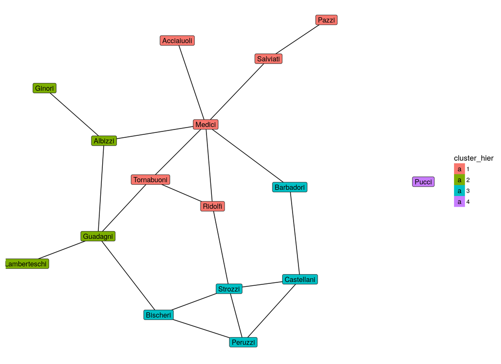

```r
hier_label_tbl <- data_frame(
    vertex.names = V(florence_igraph) %>% names()
   ,cluster_hier = florence_partition %>% membership() %>% as.character()
)

florentine_plot_layout <- florentine_fr_layout %>%
    merge(hier_label_tbl, by = 'vertex.names')

cluster_hier_plot <- ggplot(florentine_plot_layout
                           ,aes(x = x, y = y, xend = xend, yend = yend)) +
    geom_edges() +
    geom_nodelabel(aes(label = vertex.names, fill = cluster_hier)) +
    theme_blank()

cluster_hier_plot %>% plot()
```

### 1.4.2 Spectral Partitioning

We can use more direct linear algebra routines to partition the graph. To do this we construct the ‘graph Laplacian’ from the degrees of each vertex and its adjacency matrix.

$$\mathbf{L} = \mathbf{D} - \mathbf{A}$$

By analysing the eigenvalues and eigenvectors of this matrix, and recursively applying splits to the graphs based on the size of the eigenvalues, we break this network into pieces.

```r
florency_laplacian <- laplacian_matrix(florence_igraph)

flor_laplac_eigen <- eigen(florency_laplacian)

flor_laplac_eigen %>% print(digits = 2)
```

```
## eigen() decomposition
## $values
##  [1]  7.3e+00  5.5e+00  5.3e+00  4.3e+00  3.6e+00  3.4e+00  2.6e+00  2.5e+00
##  [9]  1.6e+00  1.5e+00  8.0e-01  7.0e-01  5.3e-01  3.5e-01  2.3e-16 -1.1e-16
##
## $vectors
##          [,1]   [,2]   [,3]     [,4]     [,5]     [,6]     [,7]   [,8]     [,9]
##  [1,] -0.1385  0.047 -0.016  4.3e-02  3.1e-02 -0.01724 -3.0e-03  0.068  3.4e-01
##  [2,] -0.2507 -0.177  0.152 -1.1e-01 -3.2e-01  0.59726  4.2e-01 -0.165 -5.2e-02
##  [3,] -0.1701  0.137  0.048 -1.6e-01 -1.4e-01 -0.33473  2.3e-01  0.043 -6.6e-01
##  [4,] -0.0502 -0.462 -0.043  1.8e-01 -1.8e-01 -0.51241  3.3e-01 -0.181  3.8e-01
##  [5,]  0.0275 -0.271 -0.229  5.0e-01  3.1e-01  0.41426 -1.5e-01  0.082 -9.5e-02
##  [6,]  0.0400  0.039 -0.035  3.4e-02  1.2e-01 -0.25317 -2.6e-01  0.108  9.1e-02
##  [7,]  0.1615  0.616 -0.389  2.5e-01  1.5e-01 -0.00196  4.1e-01 -0.084  2.5e-02
##  [8,] -0.0258 -0.137  0.090 -7.6e-02 -5.9e-02  0.00083 -2.5e-01  0.055 -4.4e-02
```

[output cut: 25 more lines]

We look at the eigenvalues ranked in order.

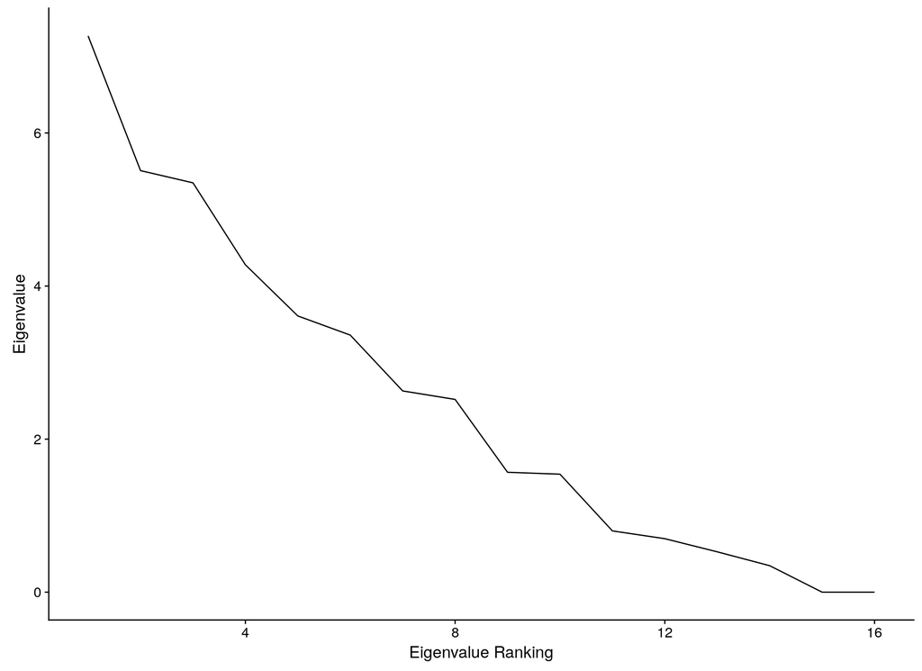

```r
ggplot() +
    geom_line(aes(x = seq_along(flor_laplac_eigen$values)
                 ,y = flor_laplac_eigen$values)) +
    expand_limits(y = 0) +
    xlab("Eigenvalue Ranking") +
    ylab("Eigenvalue")
```

We now cluster using these spectral methods

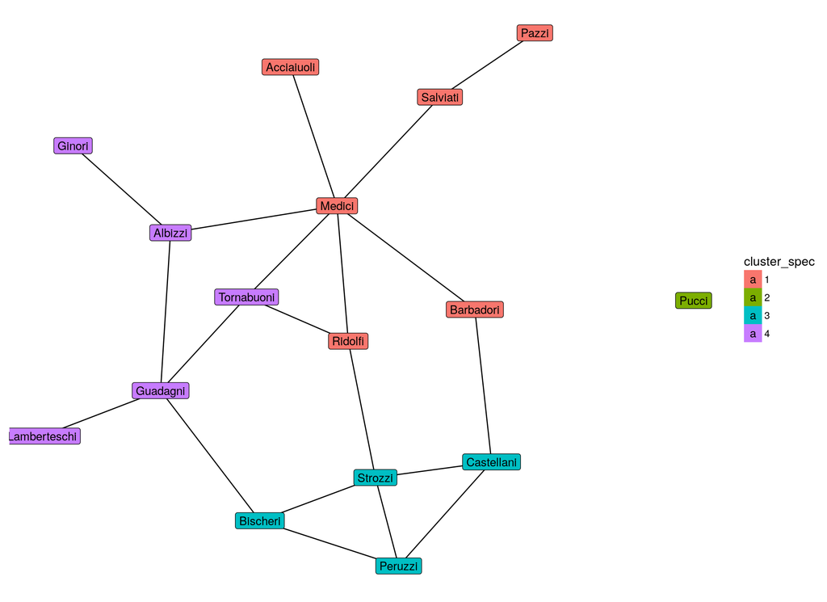

```r
florence_spec_partition <- florence_igraph %>%
    cluster_leading_eigen()

spec_label_tbl <- data_frame(
    vertex.names = V(florence_igraph) %>% names()
   ,cluster_spec = florence_spec_partition %>% membership() %>% as.character()
)

florentine_plot_layout <- florentine_fr_layout %>%
    merge(spec_label_tbl, by = 'vertex.names')

cluster_spec_plot <- ggplot(florentine_plot_layout
                           ,aes(x = x, y = y, xend = xend, yend = yend)) +
    geom_edges() +
    geom_nodelabel(aes(label = vertex.names, fill = cluster_spec)) +
    theme_blank()

cluster_spec_plot %>% plot()
```

We plot the two groupings beside each other to compare them.

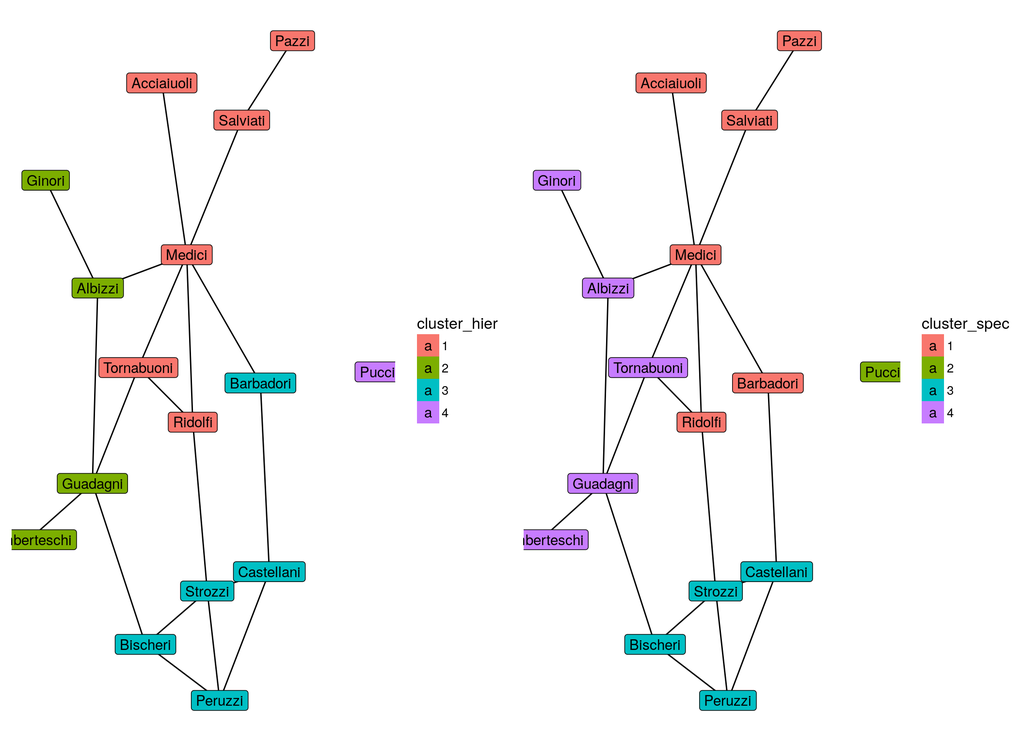

```r
plot_grid(cluster_hier_plot, cluster_spec_plot, ncol = 2)
```

### 1.4.3 Exercises

1. Run the clustering algorithms for the other network data.

## 1.5 Assortativity

*Assortativity* is a measure, analogous to correlation, that measures the tendency for nodes will similar properties to connect to one another.

The Florentine marriage data is a little unusual in that it does not contain any properties on the vertices or edges, but assortativity in degree can be calculated - measuring the tendency for high degree nodes to connect to one another)

```r
assortativity_degree(florence_igraph)
```

```
## [1] -0.374838
```

There are slightly different calculations for assortativity, depending on whether the attribute is numerical or categorical.

To test this, we will add the hierarchical clustering ID from the previous section to the Florentine graph and then measure the assortivity associated with that attribute.

```r
assortativity_nominal(florence_igraph, membership(florence_partition))
```

```
## [1] 0.614644
```

```r
assortativity_nominal(florence_igraph, membership(florence_spec_partition))
```

```
## [1] 0.548023
```

### 1.5.1 Exercises

1. Calculate the assortativity of membership for Florentine data as binary membership.
2. Calculate the assortativity for the other networks.